# Python_Assignment1

There once was a man named Michael Finnegan,  
He had whiskers on his chinnegan,  
The wind came up and blew them in ag'in,  
Poor old Michael Finnegan (begin ag'in)

```python
#2
print("There once was a man named Michael Finnegan,", end = "")
print("He had whiskers on his chinnegan,", end="")
print("The wind came up and blew them in ag'in,", end="")
print("Poor old Michael Finnegan (begin ag'in)", end = "")
```

```
There once was a man named Michael Finnegan,He had whiskers on his chinnegan,The wind came up and blew them in ag'in,Poor old Michael Finnegan (begin ag'in)
```

```python
#3
print("There once was a man named Michael Finnegan,")
print("He had whiskers on his chinnegan,")
print("The wind came up and blew them in ag'in,")
print("Poor old Michael Finnegan (begin ag'in)")
```

```
There once was a man named Michael Finnegan,
He had whiskers on his chinnegan,
The wind came up and blew them in ag'in,
Poor old Michael Finnegan (begin ag'in)
```

```python
#4.
my_name = "Meng Zhang"
print("There once was a man named " + my_name + "," )
print("He had whiskers on his chinnegan,")
print("The wind came up and blew them in ag'in,")
print("Poor old " + my_name + " (begin ag'in)")
```

```
There once was a man named Meng Zhang,
He had whiskers on his chinnegan,
The wind came up and blew them in ag'in,
Poor old Meng Zhang (begin ag'in)
```

```python
#5.
user_name = input("What's your name?")
print("There once was a man named " + user_name + "," )
print("He had whiskers on his chinnegan,")
print("The wind came up and blew them in ag'in,")
print("Poor old " + user_name + " (begin ag'in)")
```

```
What's your name? 123
There once was a man named  123,
He had whiskers on his chinnegan,
The wind came up and blew them in ag'in,
Poor old  123 (begin ag'in)
```

```python
#6.
my_name = "Meng Zhang"
print("There once was a man named {}".format(my_name) + ",")
print("He had whiskers on his chinnegan,")
print("The wind came up and blew them in ag'in,")
print("Poor old {}".format(my_name) +" (begin ag'in)")
```

```
There once was a man named Meng Zhang,
He had whiskers on his chinnegan,
The wind came up and blew them in ag'in,
Poor old Meng Zhang (begin ag'in)
```

```python
#7.
poemList = ["There once was a man named Michael Finnegan,", "He had whiskers on his chinnegan,",
            "The wind came up and blew them in ag'in,", "Poor old Michael Finnegan (begin ag'in)"]
for poemItem in poemList:
    print(poemItem)
```

```
There once was a man named Michael Finnegan,
He had whiskers on his chinnegan,
The wind came up and blew them in ag'in,
Poor old Michael Finnegan (begin ag'in)
```

1. One advantage of literate programming is it allows users to formulate and describe their thoughts with prose, supplemented by mathematical equations, as they prepare to write code blocks. This mindset is the opposite of how we usually think about code.
1. In Q4, I define a variable called my_name and put a string, "Meng Zhang", into it. Then, in the code, I use the variable, my_name, to replace the previous name, Michael Finnegan, in the poem. When I run this code, I find in the poem, "Michael Finnegan" has been replaced by "Meng Zhang".
1. In Q6, at first, I thought I could use str.format() directly. So, I tried to write, print("There once was a man named ".str.format(my_name) + ","), but it had an error and could not be run. Then I searched for it on the Internet. I found the answer. The website I found was, https://realpython.com/python-string-formatting/#2-new-style-string-formatting-strformat. The following screenshot is the useful part.

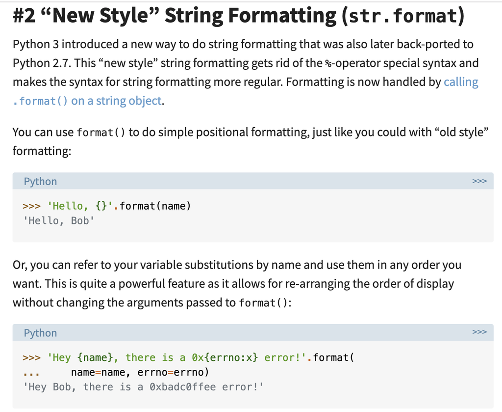

   I tried to write, print("There once was a man named {}".format(my_name) + ","), and it worked. If I was reading a forum, the questions that others asked helped me a lot. They can solve my problems and sometimes, they can guide me to think about a problem from different perspectives.